# Práctica Final

© Gerardo Tirado García

© Irene Trigueros Lorca

2023-01-16

# **Instalación y carga de librerías**

```r
# Instalamos las librerías a utilizar si no están ya instaladas
#install.packages("psych")
#install.packages("polycor")
#install.packages("ggcorrplot")
#install.packages("corrr")
#install.packages("moments") #skewness
#install.packages("dplyr") #Test de Saphiro-Wilk
#install.packages("factoextra")
#install.packages("MVN")
#install.packages("biotools")
#Cargamos las librerías que vamos a utilizar
library(psych)
library(polycor)
library(ggcorrplot)
library(corrplot)
library(corrr)
library(moments)
library(foreign)
library(reshape2)
library(knitr)
library(dplyr)
library(ggplot2)
library("factoextra")
library(stats)
library(MVN)
library(biotools)
```

Cargamos los datos de la base de datos mencionados anteriormente:

```r
datos_original<-read.spss("DB_3.sav", to.data.frame = TRUE)
```

# **Análisis exploratorio univariante**

## *Recodificaciones o agrupaciones de datos*

En primer lugar, eliminamos la primera columna, que representa a los países, ya que no nos sirven:

```r
datos<-datos_original[,-1]
```

## *Valores perdidos*

Definimos la función que nos permite identificar el porcentaje de valores perdidos de cada variable:

```r
per_not_available<-function(data, na.rm=F){
  colMeans(is.na(data))*100
}
per_not_available(datos)
```

```
## ZPOBDENS ZTMINFAN ZESPVIDA  ZPOBURB ZTMEDICO ZPAGRICU  ZPSERVI ZTLIBROP
## 0.000000 0.000000 0.000000 0.000000 0.000000 0.000000 0.000000 2.941176
## ZTEJERCI ZTPOBACT ZTENERGI
## 0.000000 0.000000 0.000000
```

Podemos observar que ninguna variable tiene valores perdidos, excepto `ZTLIBROP`, con un 2.941176% de valores perdidos (lo que se corresponde en un solo valor perdido).

Como en este paso solo tenemos que tratar con las variables que tengan más de un 5% de valores perdidos, y no tenemos ningún caso en el que esto pase, no hay más que hacer. Sin embargo, la mayor parte del análisis que tenemos que hacer requiere de que no haya valores perdidos (por ejemplo, para la correlación si hay valores perdidos, las filas y las columnas de las variables con valores perdidos se llenarán de `NA`); por lo tanto, trataremos con estos valores ahora sustituyéndolos por la media de la variable:

```r
not_available<-function(data,na.rm=F){
  data[is.na(data)]<-mean(data,na.rm=T)
  data
}
datos$ZTLIBROP<-not_available(datos$ZTLIBROP)
```

## *Análisis descriptivo numérico clásico*

Podemos observar los siguientes valores característicos:

- Mínimo
- Primer cuartil
- Mediana
- Media
- Tercer cuartil
- Máximo

de cada variable utilizando la función `summary`:

```r
summary(datos)
```

```
##     ZPOBDENS          ZTMINFAN          ZESPVIDA          ZPOBURB
##  Min.   :-1.0778   Min.   :-1.1026   Min.   :-2.1453   Min.   :-1.7697
##  1st Qu.:-0.8497   1st Qu.:-0.9586   1st Qu.:-0.7460   1st Qu.:-0.7320
##  Median :-0.1616   Median :-0.3931   Median : 0.2781   Median : 0.1268
##  Mean   : 0.0000   Mean   : 0.0000   Mean   : 0.0000   Mean   : 0.0000
##  3rd Qu.: 0.5547   3rd Qu.: 0.8985   3rd Qu.: 0.9033   3rd Qu.: 0.8148
##  Max.   : 2.8616   Max.   : 1.9048   Max.   : 1.2486   Max.   : 1.5096
##     ZTMEDICO          ZPAGRICU          ZPSERVI            ZTLIBROP
##  Min.   :-1.1473   Min.   :-1.2342   Min.   :-1.88521   Min.   :-0.9696
##  1st Qu.:-0.8829   1st Qu.:-0.8480   1st Qu.:-0.72858   1st Qu.:-0.9145
##  Median :-0.2916   Median :-0.2134   Median : 0.03541   Median :-0.2442
##  Mean   : 0.0000   Mean   : 0.0000   Mean   : 0.00000   Mean   : 0.0000
##  3rd Qu.: 0.8694   3rd Qu.: 0.7115   3rd Qu.: 0.85176   3rd Qu.: 0.6923
##  Max.   : 2.3717   Max.   : 1.9052   Max.   : 1.62885   Max.   : 2.4024
##     ZTEJERCI           ZTPOBACT          ZTENERGI
##  Min.   :-0.86586   Min.   :-2.1341   Min.   :-0.9507
##  1st Qu.:-0.59889   1st Qu.:-0.6735   1st Qu.:-0.7813
##  Median :-0.20626   Median :-0.1067   Median :-0.3900
##  Mean   : 0.00000   Mean   : 0.0000   Mean   : 0.0000
##  3rd Qu.: 0.07996   3rd Qu.: 0.8789   3rd Qu.: 0.5828
##  Max.   : 4.42620   Max.   : 1.7045   Max.   : 2.7498
```

Podemos comprobar la simetría de cada variable utilizando la función `skewness`:

```r
skewness(datos) #https://www.programmingr.com/statistics/skewness/
```

```
##   ZPOBDENS   ZTMINFAN   ZESPVIDA    ZPOBURB   ZTMEDICO   ZPAGRICU    ZPSERVI
##  1.0679539  0.5477565 -0.5802673 -0.3189850  0.4909934  0.5918253 -0.1239223
##   ZTLIBROP   ZTEJERCI   ZTPOBACT   ZTENERGI
##  0.8170779  2.8653904 -0.1284517  1.2270338
```

Sabemos que si la media se encuentra a la derecha de la mediana, obtendremos un skewness positivo; en caso contrario, obtendremos un skewness negativo.

Podemos comprobar gráficamente la simetría de las variables utilizando:

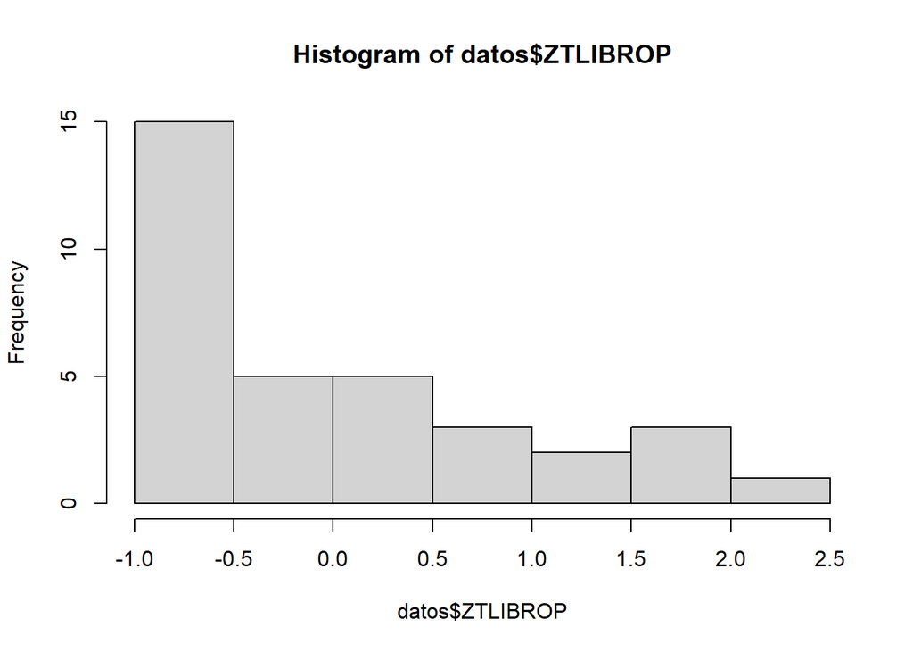

```r
hist(x = datos$ZTLIBROP)
```

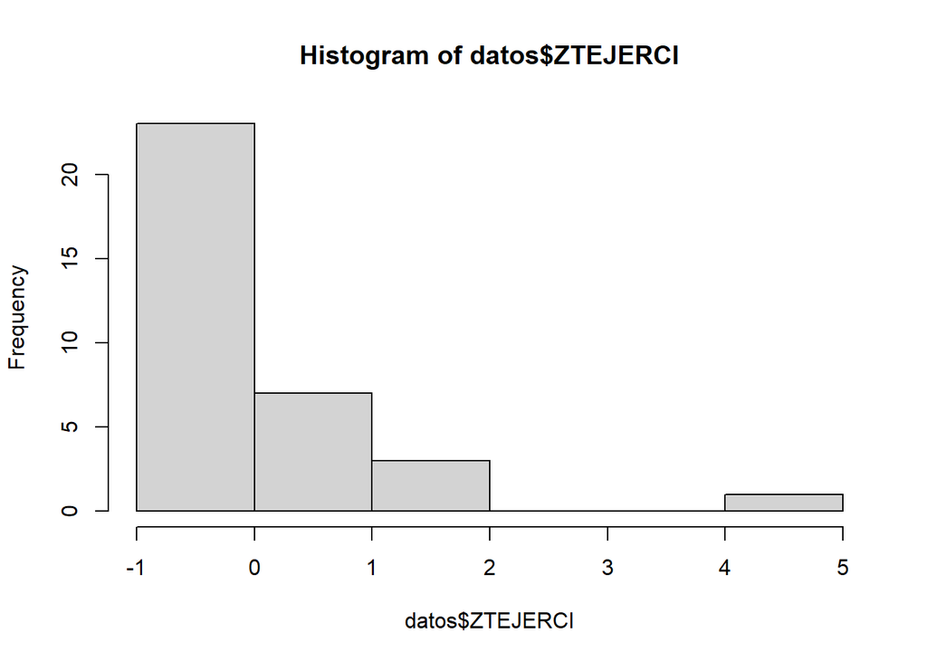

```r
hist(x = datos$ZTEJERCI)
```

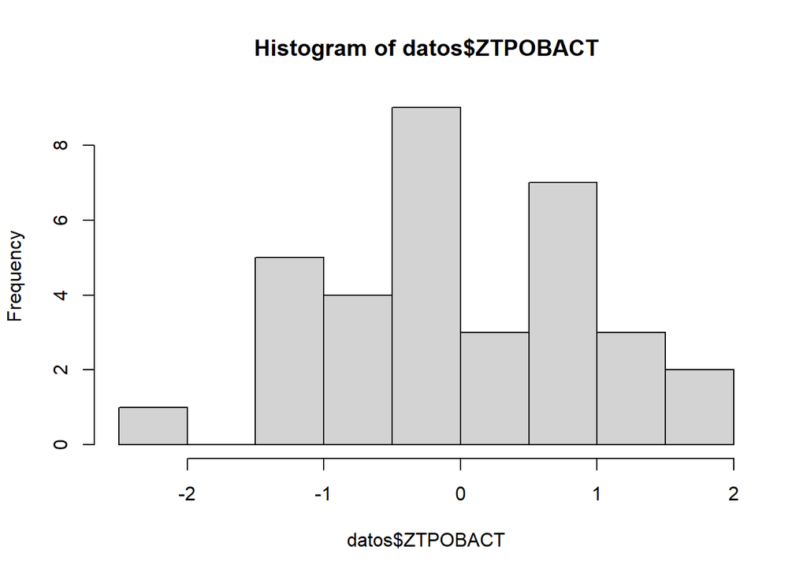

```r
hist(x = datos$ZTPOBACT)
```

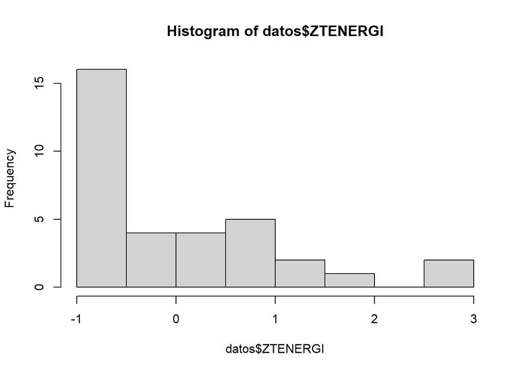

```r
hist(x = datos$ZTENERGI)
```

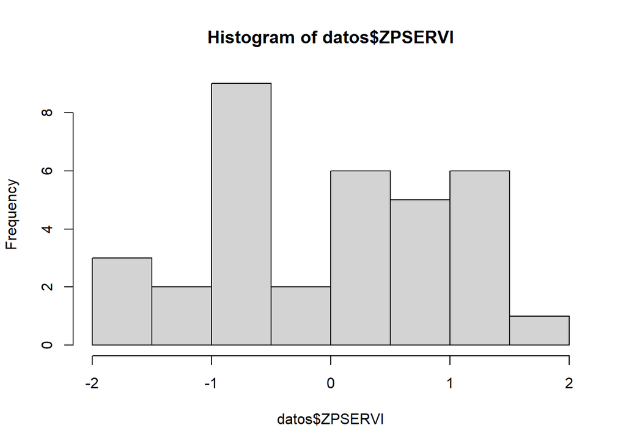

```r
hist(x = datos$ZPSERVI)
```

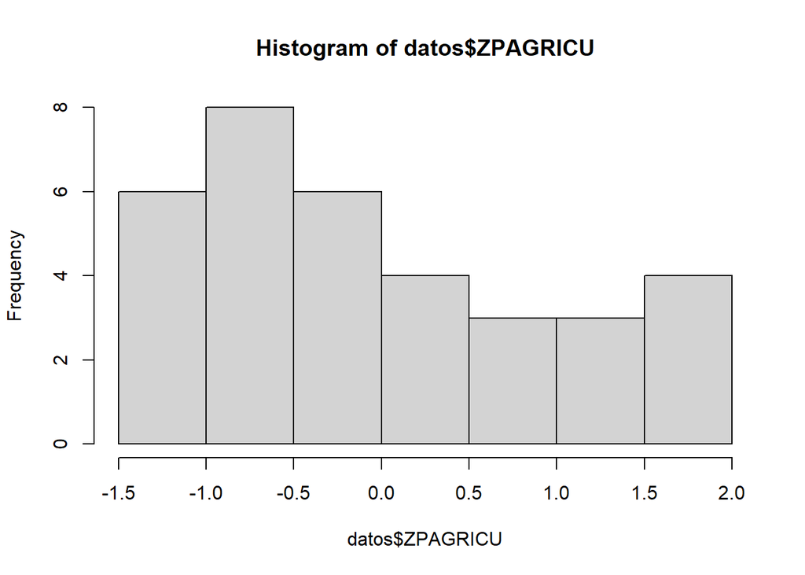

```r
hist(x = datos$ZPAGRICU)
```

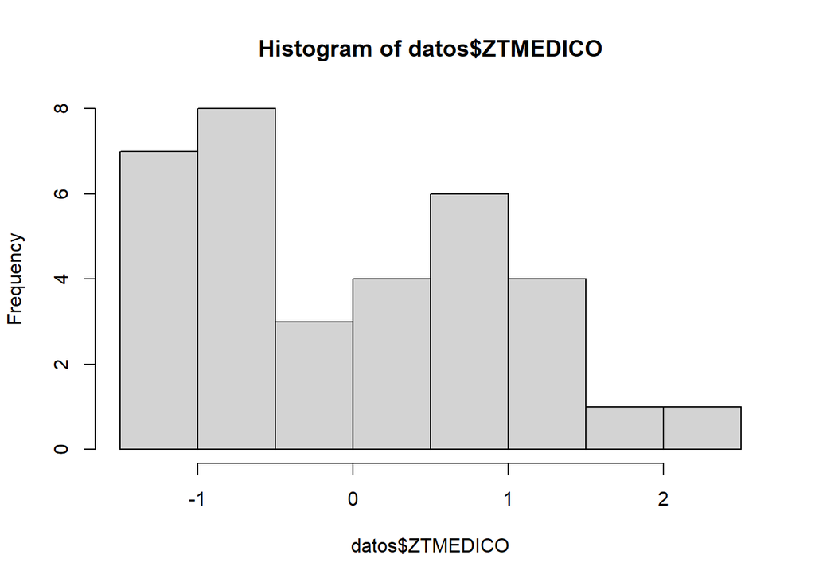

```r
hist(x = datos$ZTMEDICO)
```

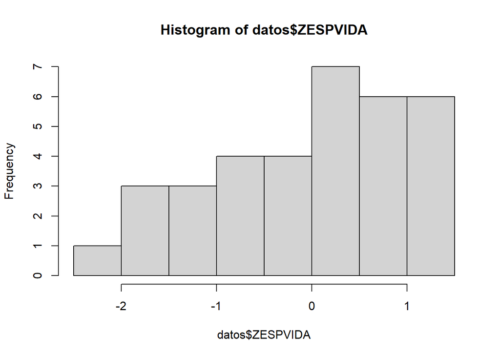

```r
hist(x = datos$ZESPVIDA)
```

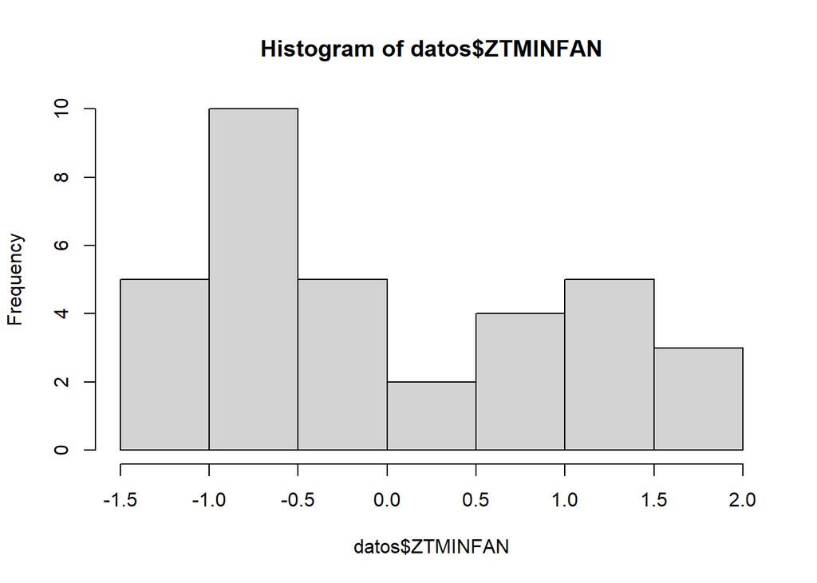

```r
hist(x = datos$ZTMINFAN)
```

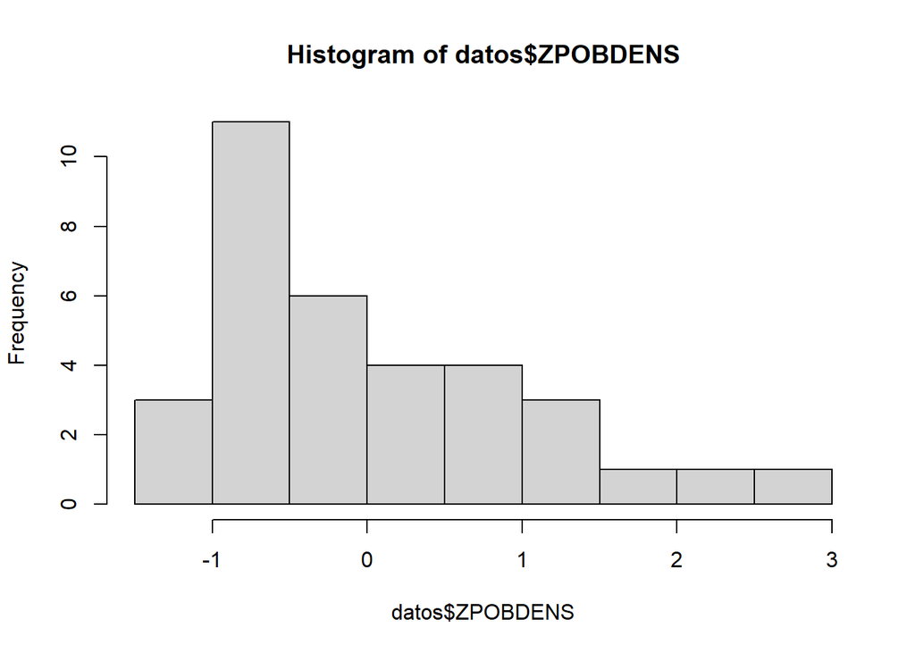

```r
hist(x = datos$ZPOBDENS)
```

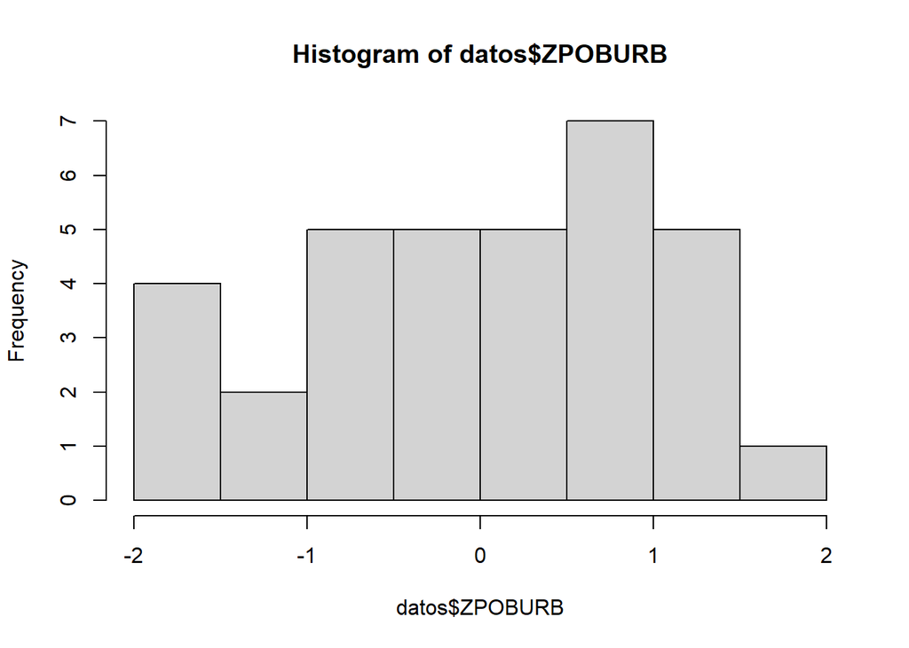

```r
hist(x = datos$ZPOBURB)
```

La curtosis mide cómo de achatada o apuntada es la curva y cómo se agrupan valores en torno a la media (la curtosis de una distribución normal es 3):

- La curtosis de una distribución normal es 3.
- Si una distribución dada tiene una curtosis menor que 3, se dice que es *playkurtic*, lo que significa que tiende a producir menos valores atípicos y menos extremos que la distribución normal.
- Si una distrubicón dada tiene una curtosis mayor que 3, se dice que es *leptocúrtica*, lo que significa que tiende a producir más valores atípicos que la distribución normal.

Se puede calcular utilizando la función `kurtosis`:

```r
kurtosis(datos) #https://statologos.com/asimetria-curtosis-en-r/
```

```
##  ZPOBDENS  ZTMINFAN  ZESPVIDA   ZPOBURB  ZTMEDICO  ZPAGRICU   ZPSERVI  ZTLIBROP
##  3.542159  1.796001  2.156273  1.902481  2.065480  2.055664  1.911288  2.524152
##  ZTEJERCI  ZTPOBACT  ZTENERGI
## 12.634918  2.111551  3.912472
```

## *Valores extremos (outliers)*

El objetivo es el de localizar outliers que puedan dar lugar a resultados erróneos ya que el ACP es muy sensible a valores extremos. Un diagrama de cajas puede dar esta primera información:

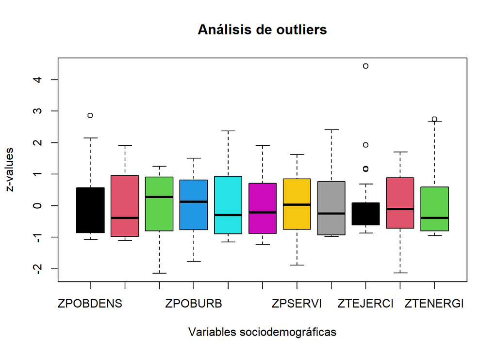

```r
boxplot(datos,main="Análisis de outliers",
        xlab="Variables sociodemográficas",
        ylab="z-values",
        col=c(1:11))
```

Al obtener el gráfico con estos datos, se observa que tanto `ZOPBENDS`, `ZJEJERCI` y `ZTENERGI` presentan outliers.

```r
outlier<-function(data,na.rm=T){
  H<-1.5*IQR(data)
  data[data<quantile(data,0.25,na.rm = T)-H]<-NA
  data[data>quantile(data,0.75, na.rm = T)+H]<-NA
  data[is.na(data)]<-mean(data, na.rm = T)
  H<-1.5*IQR(data)
  if (TRUE %in% (data<quantile(data,0.25,na.rm = T)-H) | TRUE %in% (data>quantile(data,0.75,na.rm = T)+H))
    outlier(data)
  else
    return(data)
}
```

Entonces aplicamos esta función a las variables donde hemos encontrado outliers:

```r
datos$ZPOBDENS <- outlier(datos$ZPOBDENS)
datos$ZTENERGI <- outlier(datos$ZTENERGI)
datos$ZTEJERCI <- outlier(datos$ZTEJERCI)
```

Y volvemos a mostrar el diagrama de cajas con estos nuevos cambios:

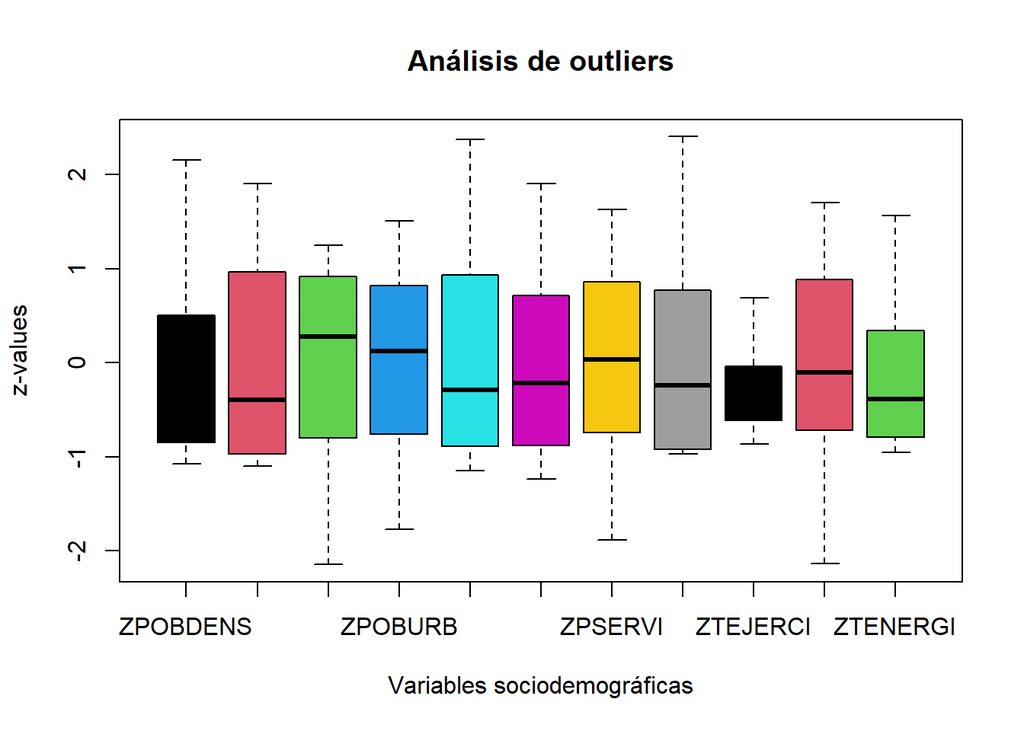

```r
boxplot(datos,main="Análisis de outliers",
        xlab="Variables sociodemográficas",
        ylab="z-values",
        col=c(1:11))
```

Al obtener el gráfico con estos datos, se observa que ya ninguna variable presenta outliers.

## *Supuesto de normalidad*

### Normalidad con gráficas qqplot

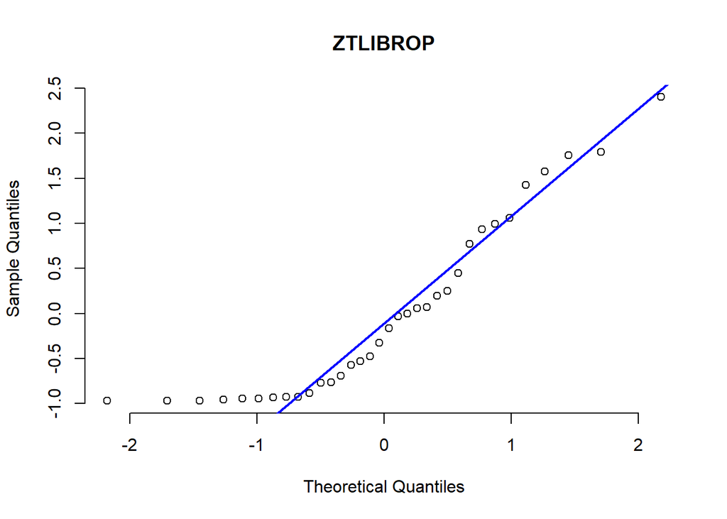

```r
qqnorm(datos$ZTLIBROP, main="ZTLIBROP", pch=1, frame = FALSE)
qqline(datos$ZTLIBROP, col = 'blue', lwd=2)
```

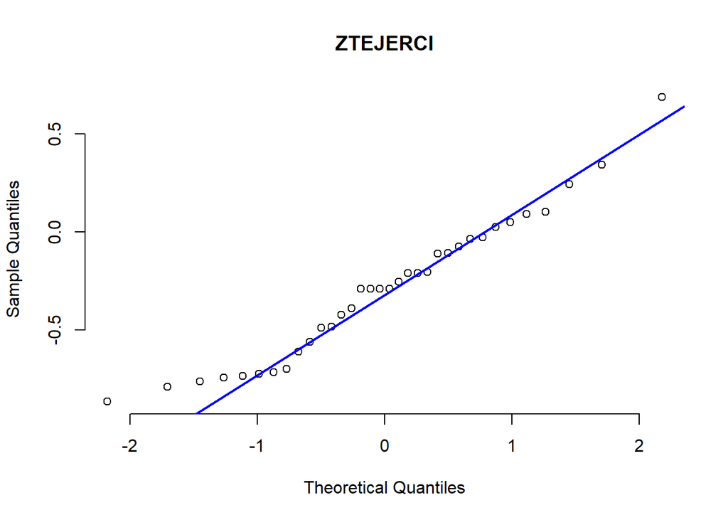

```r
qqnorm(datos$ZTEJERCI, main="ZTEJERCI", pch=1, frame = FALSE)
qqline(datos$ZTEJERCI, col = 'blue', lwd=2)
```

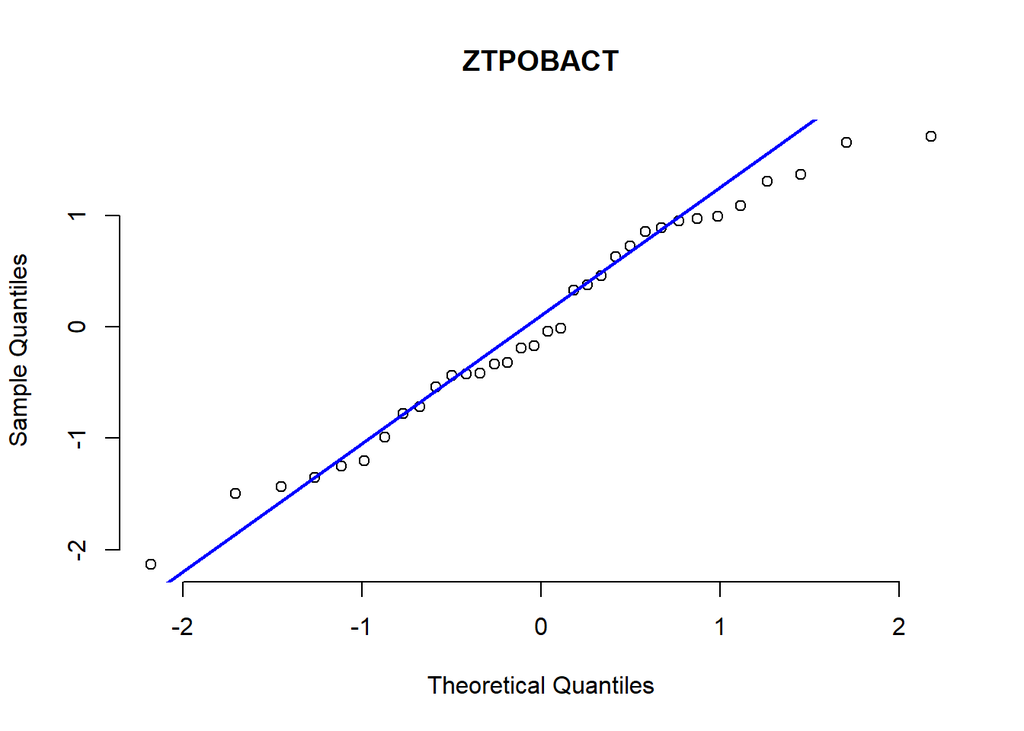

```r
qqnorm(datos$ZTPOBACT, main="ZTPOBACT", pch=1, frame = FALSE)
qqline(datos$ZTPOBACT, col = 'blue', lwd=2)
```

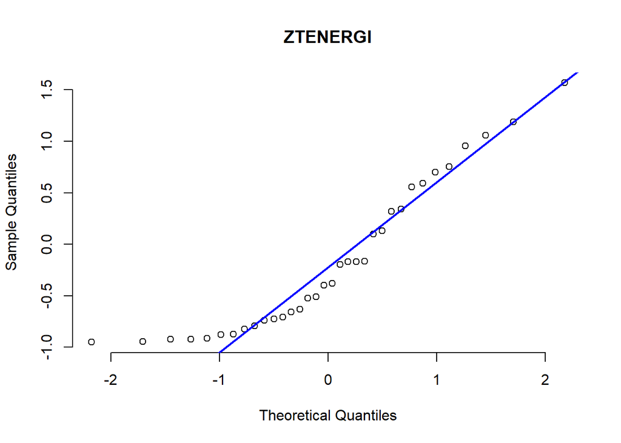

```r
qqnorm(datos$ZTENERGI, main="ZTENERGI", pch=1, frame = FALSE)
qqline(datos$ZTENERGI, col = 'blue', lwd=2)
```

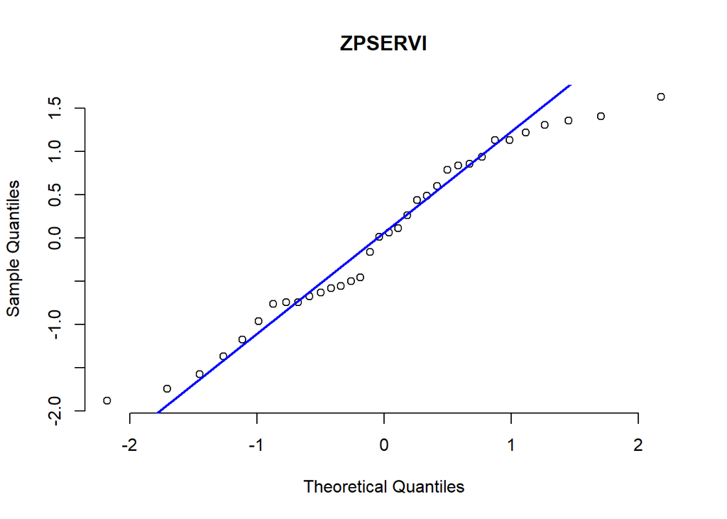

```r
qqnorm(datos$ZPSERVI, main="ZPSERVI", pch=1, frame = FALSE)
qqline(datos$ZPSERVI, col = 'blue', lwd=2)
```

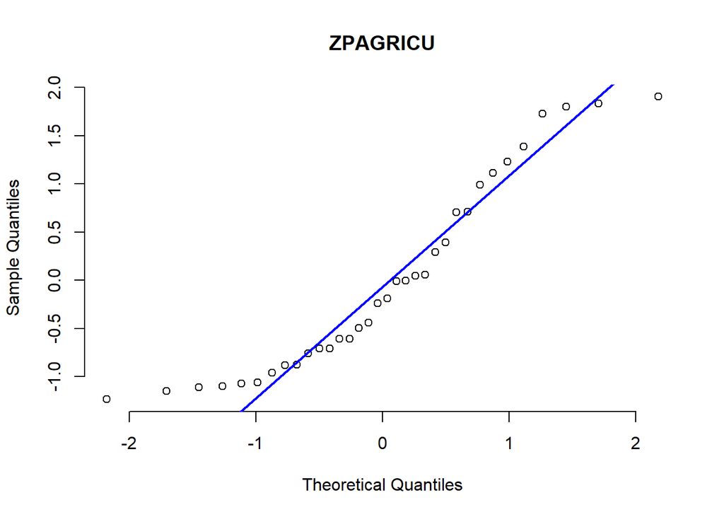

```r
qqnorm(datos$ZPAGRICU, main="ZPAGRICU", pch=1, frame = FALSE)
qqline(datos$ZPAGRICU, col = 'blue', lwd=2)
```

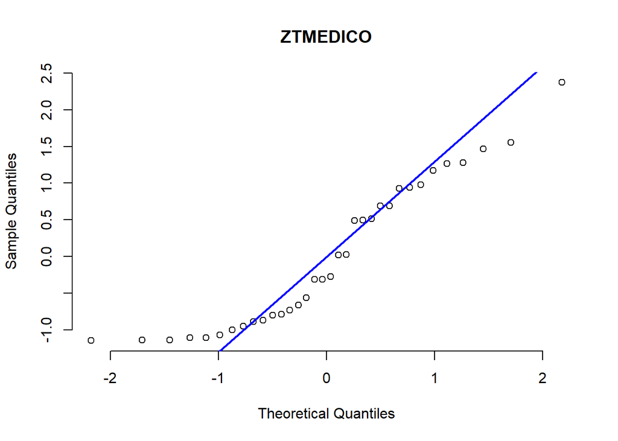

```r
qqnorm(datos$ZTMEDICO, main="ZTMEDICO", pch=1, frame = FALSE)
qqline(datos$ZTMEDICO, col = 'blue', lwd=2)
```

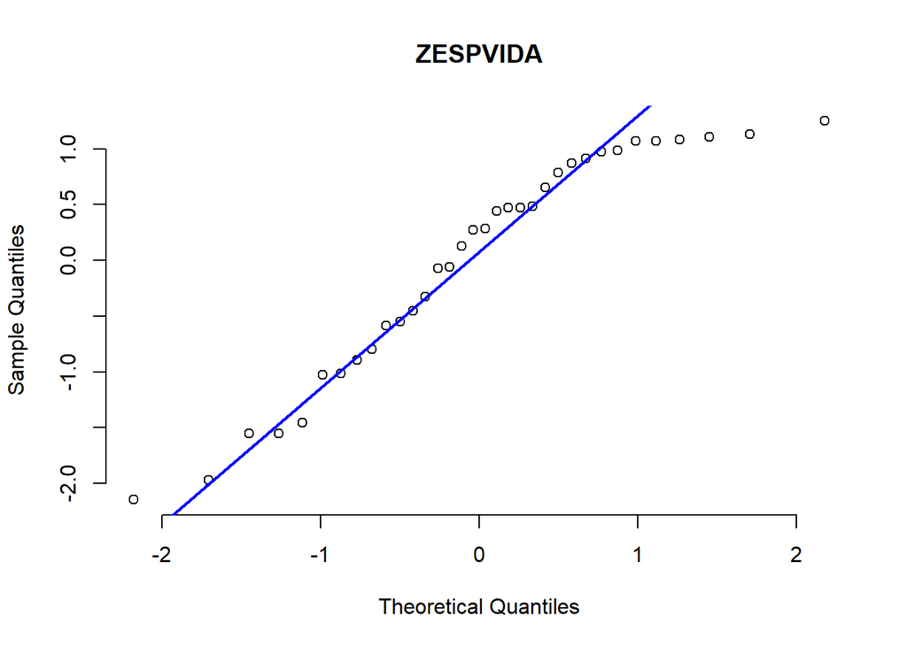

```r
qqnorm(datos$ZESPVIDA, main="ZESPVIDA", pch=1, frame = FALSE)
qqline(datos$ZESPVIDA, col = 'blue', lwd=2)
```

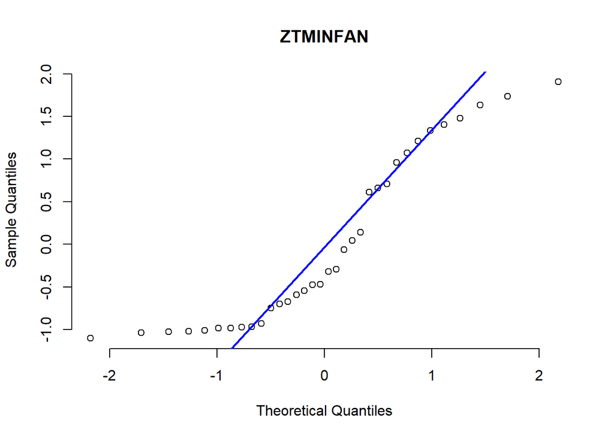

```r
qqnorm(datos$ZTMINFAN, main="ZTMINFAN", pch=1, frame = FALSE)
qqline(datos$ZTMINFAN, col = 'blue', lwd=2)
```

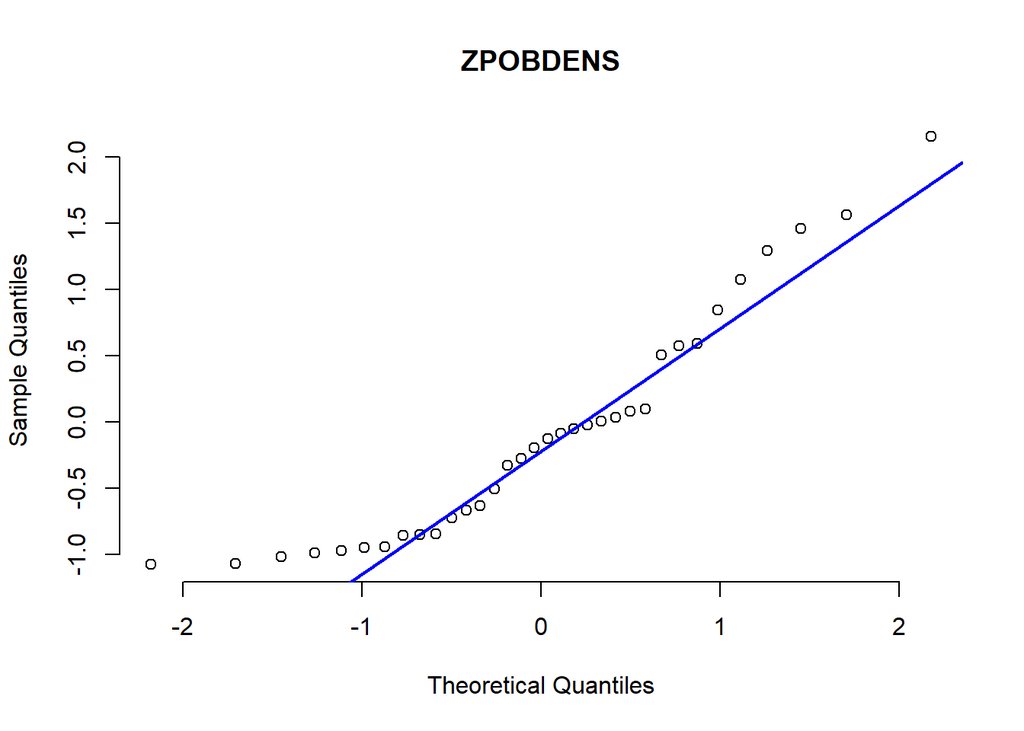

```r
qqnorm(datos$ZPOBDENS, main="ZPOBDENS", pch=1, frame = FALSE)
qqline(datos$ZPOBDENS, col = 'blue', lwd=2)
```

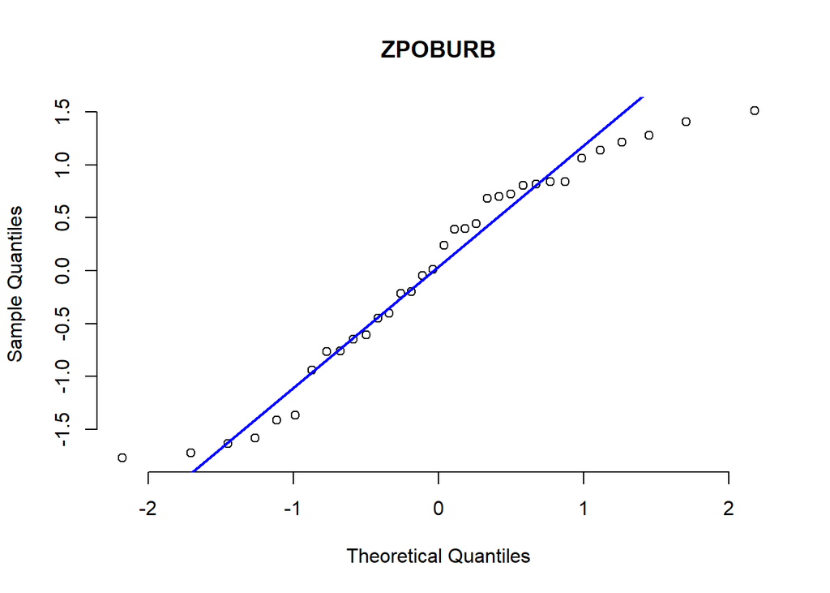

```r
qqnorm(datos$ZPOBURB, main="ZPOBURB", pch=1, frame = FALSE)
qqline(datos$ZPOBURB, col = 'blue', lwd=2)
```

Este análisis exploratorio puede darnos una idea de la posible distribución normal de las variables univariadas, pero siempre es mejor hacer los respectivos test de normalidad.

### Test de Saphiro-Wilk

Para ello haremos el test de Saphiro-Wilk que se usa para comprobar la normalidad de un conjunto de datos. En este caso, lo aplicaremos a cada variable. Si el p-valor obtenido por la variables es mayor que 0.05, la variable sigue una distribución normal, si no, no.

```r
datos_tidy <- melt(datos, value.name = "valor")
aggregate(valor ~ variable, data = datos_tidy,
          FUN = function(x){shapiro.test(x)$p.value})
```

```
##    variable        valor
## 1  ZPOBDENS 0.0068268640
## 2  ZTMINFAN 0.0007802849
## 3  ZESPVIDA 0.0123936006
## 4   ZPOBURB 0.0602666387
## 5  ZTMEDICO 0.0060637955
## 6  ZPAGRICU 0.0051266650
## 7   ZPSERVI 0.1890134480
## 8  ZTLIBROP 0.0009239641
## 9  ZTEJERCI 0.2857402686
## 10 ZTPOBACT 0.5098175256
## 11 ZTENERGI 0.0028658587
```

```r
#x>0.05 -> ZPOBURB, ZPSERVI, ZTEJERCI, ZTPOBACT
```

Podemos observar que el p-valor es mayor que 0.05 solo para ZPOBURB, ZPSERVI, ZTEJERCI y ZTPOBACT por lo que son las únicas variables que siguen unas distribución normal.

# **Análisis exploratorio multivariante**

## *Correlación*

```r
cor(datos)
```

```
##             ZPOBDENS   ZTMINFAN   ZESPVIDA     ZPOBURB   ZTMEDICO     ZPAGRICU
## ZPOBDENS  1.00000000 -0.2109635  0.1735014  0.05132529  0.0525974 -0.018865672
## ZTMINFAN -0.21096354  1.0000000 -0.9668834 -0.75749544 -0.7509189  0.752161039
## ZESPVIDA  0.17350137 -0.9668834  1.0000000  0.78714604  0.7361282 -0.753537421
## ZPOBURB   0.05132529 -0.7574954  0.7871460  1.00000000  0.6353621 -0.938022359
## ZTMEDICO  0.05259740 -0.7509189  0.7361282  0.63536205  1.0000000 -0.674513147
## ZPAGRICU -0.01886567  0.7521610 -0.7535374 -0.93802236 -0.6745131  1.000000000
## ZPSERVI  -0.05804281 -0.5901653  0.6121270  0.89001519  0.4446255 -0.907218449
## ZTLIBROP  0.23071577 -0.7157201  0.7004692  0.66106622  0.6093143 -0.666850181
## ZTEJERCI  0.05154113 -0.0254503  0.1017843  0.03566091  0.1513290 -0.007128371
## ZTPOBACT  0.23749261 -0.6032470  0.5411995  0.15488847  0.5336484 -0.147150671
## ZTENERGI  0.17123880 -0.7155678  0.6651297  0.61549363  0.7507638 -0.688730826
##              ZPSERVI   ZTLIBROP     ZTEJERCI    ZTPOBACT   ZTENERGI
## ZPOBDENS -0.05804281  0.2307158  0.051541133  0.23749261  0.1712388
## ZTMINFAN -0.59016525 -0.7157201 -0.025450301 -0.60324698 -0.7155678
## ZESPVIDA  0.61212697  0.7004692  0.101784303  0.54119951  0.6651297
## ZPOBURB   0.89001519  0.6610662  0.035660910  0.15488847  0.6154936
## ZTMEDICO  0.44462549  0.6093143  0.151329048  0.53364837  0.7507638
## ZPAGRICU -0.90721845 -0.6668502 -0.007128371 -0.14715067 -0.6887308
## ZPSERVI   1.00000000  0.5044833 -0.173017490 -0.05616141  0.4159030
## ZTLIBROP  0.50448334  1.0000000  0.113918652  0.41591469  0.6602394
## ZTEJERCI -0.17301749  0.1139187  1.000000000 -0.07216152  0.1076248
## ZTPOBACT -0.05616141  0.4159147 -0.072161520  1.00000000  0.6004197
## ZTENERGI  0.41590296  0.6602394  0.107624821  0.60041968  1.0000000
```

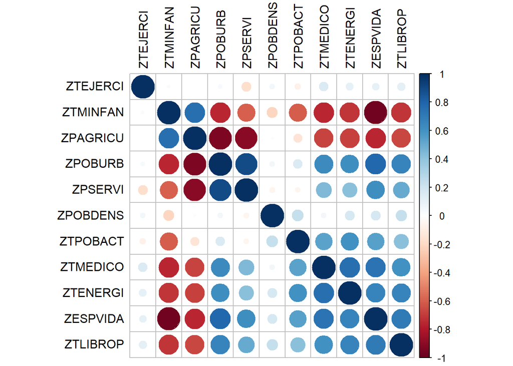

```r
corrplot(cor(datos), order = "hclust", tl.col='black', tl.cex=1)
```

La prueba de esfericidad de Bartlett contrasta la hipótesis nula de que la matriz de correlaciones es una matriz identidad, en cuyo caso no existirían correlaciones significativas entre las variables y el modelo factorial no sería pertinente.

```r
cortest.bartlett(datos) #https://rpubs.com/PacoParra/293407
```

```
## R was not square, finding R from data
```

```
## $chisq
## [1] 387.5628
##
## $p.value
## [1] 1.583951e-51
##
## $df
## [1] 55
```

## *Valores perdidos*

Ya han sido tratados en el apartado del análisis univariante.

## *Posibilidad de reducción de la dimensión*

### *Mediante variables observables*

Es conveniente elegir el número óptimo de componentes principales. El siguiente código fuente realiza el ACP, obteniendo los vectores propios que generan cada componente, así como sus valores propios que corresponden a la varianza de cada una.

La función `prcomp` del paquete base de R realiza este análisis. Pasamos los parámetros `scale` y `center` a `TRUE` para considerar los datos originales normalizados:

```r
# Realización del ACP
PCA<-prcomp(datos, scale=T, center = T)
```

El campo `rotation` del objeto `PCA` es una matriz cuyas columnas son los coeficientes de las componentes principales, es decir, el peso de cada variable en la correspondiente componente principal.

```r
PCA$rotation
```

```
##                  PC1         PC2         PC3          PC4         PC5
## ZPOBDENS  0.06796131  0.39036079  0.07578571 -0.873056137  0.05981546
## ZTMINFAN -0.37529798 -0.11573027 -0.08212636 -0.014741875  0.41788865
## ZESPVIDA  0.37165513  0.07270402 -0.00407411  0.012970861 -0.53281544
## ZPOBURB   0.35808785 -0.29124050 -0.06094609 -0.113795410 -0.05152603
## ZTMEDICO  0.33374417  0.13909259 -0.09587119  0.280930962  0.15782496
## ZPAGRICU -0.36224935  0.29940891  0.04348437  0.061235615 -0.15998056
## ZPSERVI   0.29607632 -0.48878963  0.09183567 -0.148420697 -0.03064997
## ZTLIBROP  0.32594252  0.08892433 -0.07078859 -0.135187927  0.28062939
## ZTEJERCI  0.02397325  0.17948476 -0.93319975 -0.006241743 -0.12518016
## ZTPOBACT  0.20289865  0.56167354  0.29659750  0.281932179 -0.11796713
## ZTENERGI  0.33155119  0.20152127 -0.02054058  0.148110844  0.61275026
##                  PC6         PC7         PC8          PC9        PC10
## ZPOBDENS -0.24337351  0.09619809 -0.04353317  0.022846323 -0.01646372
## ZTMINFAN -0.01756878  0.05245475 -0.39097670 -0.157260993 -0.47091956
## ZESPVIDA  0.03028763 -0.04105430  0.29289664 -0.091799724 -0.54354628
## ZPOBURB  -0.07065324 -0.10651593 -0.29868358 -0.792450091  0.16228759
## ZTMEDICO -0.36060911  0.78403566 -0.06560314  0.001929436 -0.06125296
## ZPAGRICU  0.13248858  0.09343760 -0.01200167 -0.325592955 -0.48343682
## ZPSERVI  -0.07352269 -0.09280074 -0.37422057  0.449245272 -0.39418278
## ZTLIBROP  0.85707761  0.21913126 -0.01229527  0.015266047 -0.02755826
## ZTEJERCI -0.02870986 -0.16141551 -0.18218984  0.127931321  0.01085377
## ZTPOBACT  0.02948798 -0.25103160 -0.61023870  0.097328148  0.08409493
## ZTENERGI -0.21278600 -0.45367225  0.34643517 -0.066593066 -0.23535405
##                  PC11
## ZPOBDENS -0.016686681
## ZTMINFAN -0.511610948
## ZESPVIDA -0.424556791
## ZPOBURB   0.088144761
## ZTMEDICO  0.058614024
## ZPAGRICU  0.617855535
## ZPSERVI   0.361609762
## ZTLIBROP  0.008370356
## ZTEJERCI  0.063899183
## ZTPOBACT -0.095710436
## ZTENERGI  0.143880098
```

En el campo `sdev` del objeto `PCA` y con la función summary aplicada al objeto, obtenemos información relevante: desviaciones típicas de cada componente principal, proporción de varianza explicada y acumulada:

```r
PCA$sdev
```

```
##  [1] 2.4818030 1.2805818 1.0311152 0.9515420 0.6448055 0.6027181 0.4818699
##  [8] 0.3354192 0.2491626 0.1641974 0.1390789
```

```r
summary(PCA)
```

```
## Importance of components:
##                           PC1    PC2     PC3     PC4    PC5     PC6     PC7
## Standard deviation     2.4818 1.2806 1.03112 0.95154 0.6448 0.60272 0.48187
## Proportion of Variance 0.5599 0.1491 0.09665 0.08231 0.0378 0.03302 0.02111
## Cumulative Proportion  0.5599 0.7090 0.80568 0.88799 0.9258 0.95881 0.97992
##                            PC8     PC9    PC10    PC11
## Standard deviation     0.33542 0.24916 0.16420 0.13908
## Proportion of Variance 0.01023 0.00564 0.00245 0.00176
## Cumulative Proportion  0.99015 0.99579 0.99824 1.00000
```

Los siguientes gráficos ilustran el comportamiento de la varianza explicada por cada componente principal, así como el comportamiento de la varianza explicada acumulada:

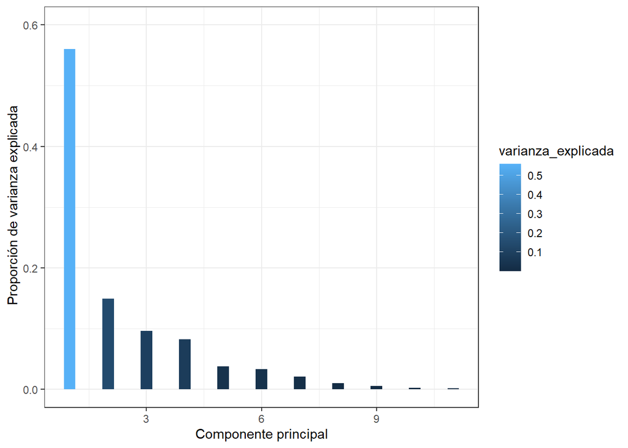

```r
# Proporción de varianza explicada
varianza_explicada <- PCA$sdev^2 / sum(PCA$sdev^2)
ggplot(data = data.frame(varianza_explicada, pc = 1:11),
       aes(x = pc, y = varianza_explicada, fill=varianza_explicada )) +
  geom_col(width = 0.3) +
  scale_y_continuous(limits = c(0,0.6)) + theme_bw() +
  labs(x = "Componente principal", y= " Proporción de varianza explicada")
```

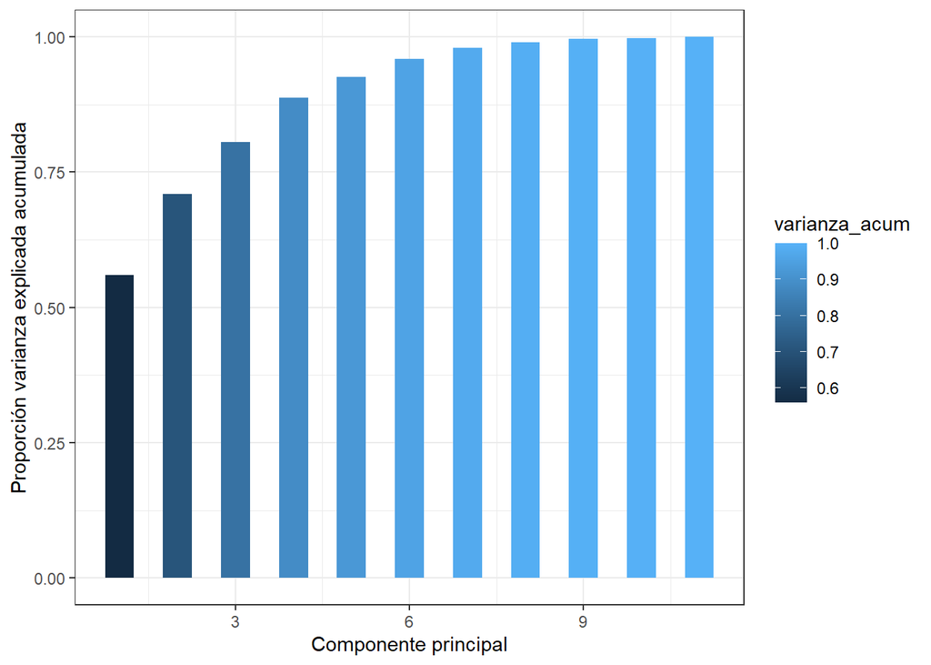

```r
# Proporción de varianza explicada acumulada
varianza_acum<-cumsum(varianza_explicada)
ggplot( data = data.frame(varianza_acum, pc = 1:11),
        aes(x = pc, y = varianza_acum ,fill=varianza_acum )) +
  geom_col(width = 0.5) +
  scale_y_continuous(limits = c(0,1)) +
  theme_bw() +
  labs(x = "Componente principal",
       y = "Proporción varianza explicada acumulada")
```

#### Selección del número de componentes principales óptimo

Una vez hecho esto, existen diferentes métodos para elegir el número de componentes principales con las que trabajar:

- Método del codo (Cuadras, 2007)
- A criterio del investigador que elige un porcentaje mínimo de varianza explicada por las componentes principales (no es fiable porque puede dar más de las necesarias).
- Regla de Abdi et al: Se promedia las varianzas explicadas por las componentes principales y se seleccionan aquellas cuya proporción de varianza explicada supera la media.

En este caso, utilizaremos tanto la Regla de Adbi et al como el criterio del investigador, eligiendo 4 componentes principales. Ya que las varianzas explicadas por solo 3 componentes supera le media, pero con la cuarta no se queda muy por debajo de la media y conseguimos alcanzar el 85% de la varianza explicada acumulada:

```r
PCA$sdev^2
```

```
##  [1] 6.15934602 1.63988972 1.06319852 0.90543213 0.41577420 0.36326910
##  [7] 0.23219856 0.11250601 0.06208202 0.02696079 0.01934294
```

```r
mean(PCA$sdev^2)
```

```
## [1] 1
```

Cada componente principal se obtiene de forma sencilla como combinación lineal de todas las variables con los coeficientes que indican las columnas de la matriz de rotación.

#### Representación gráfica de las componentes principales

Podemos mostrar las comparativas entre las distintas componentes principales analizando qué variables tienen más peso para la definición de cada componente principal utilizando la función `fviz_pca_var`:

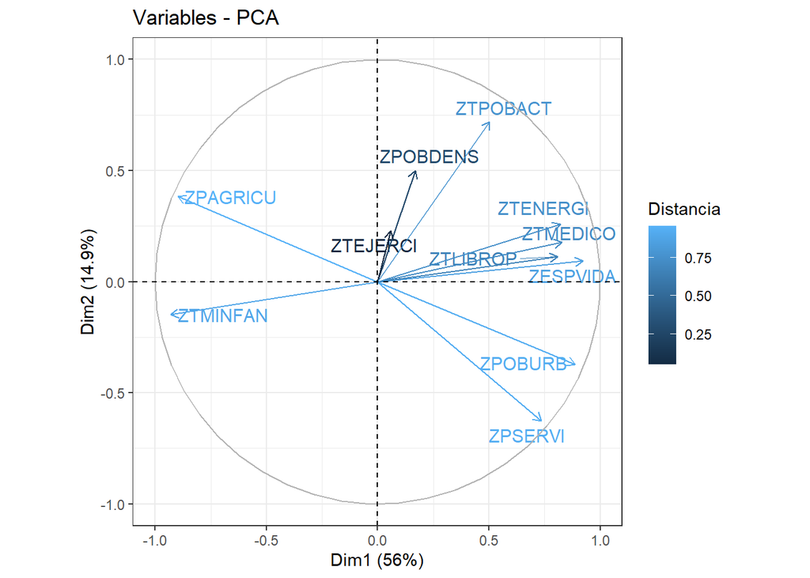

```r
fviz_pca_var(PCA,
             repel=TRUE,col.var="cos2",
             legend.title="Distancia")+theme_bw()
```

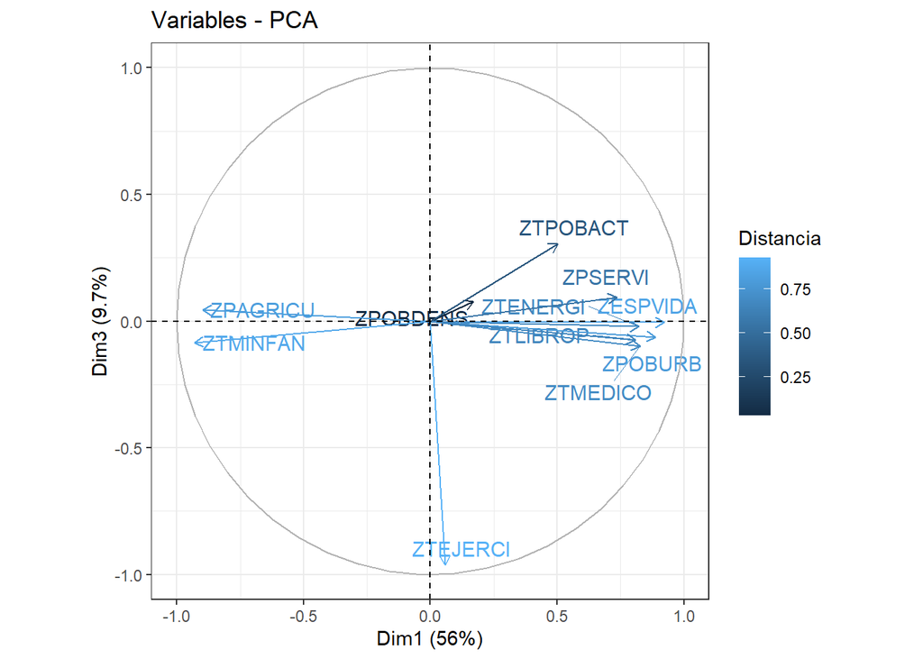

```r
fviz_pca_var(PCA,axes=c(1,3),
             repel=TRUE,col.var="cos2",
             legend.title="Distancia")+theme_bw()
```

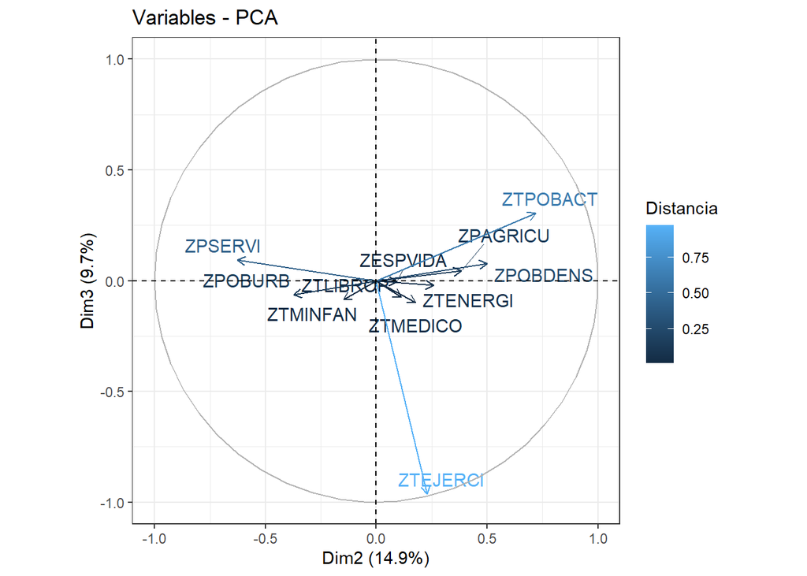

```r
fviz_pca_var(PCA,axes=c(2,3),
             repel=TRUE,col.var="cos2",
             legend.title="Distancia")+theme_bw()
```